# second week: Introduction to R and Rstudio

Mobile Data

Ali Gorji

2018-02-21 01:56:10

# تمرین سری دوم: تلفن همراه شناسی!

> با استفاده از داده های گوشی های همراه به سوالات زیر پاسخ دهید. برای رسم نمودار از پکیج ggplot2 استفاده کنید.

۱. کدام شرکت بیشترین تعداد گوشی را تولید کرده است؟ نمودار ستونی ۲۰ شرکت برتر بر حسب تعداد گوشی تولید کرده را رسم کنید.

```r
library(dplyr)
```

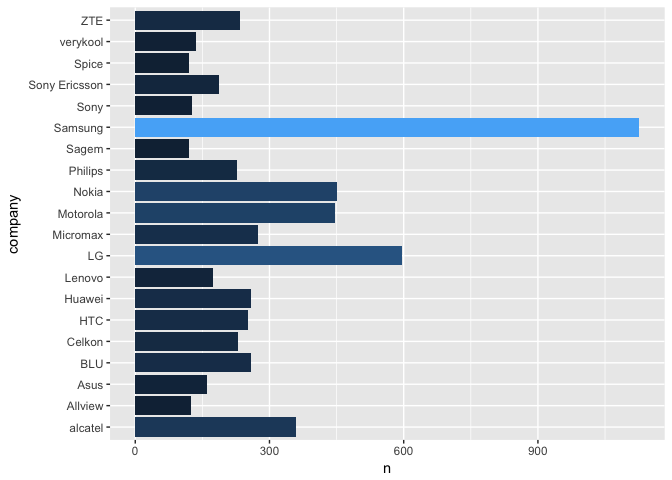

```r
library(ggplot2)
mobile <- read.csv("mobile_data.csv")
md <- as.tbl(mobile)
md %>% group_by(company) %>% count() %>% arrange(desc(n)) %>% head(20) -> top20
ggplot(top20, aes(x=company, y=n, fill = n)) + geom_col() +coord_flip() + guides(fill = FALSE)
```

۲. نمودار زمانی طول عرض ضخامت و کیفیت دوربین گوشی ها را بکشید و به نمودار هر یک مدل خطی اضافه کنید.

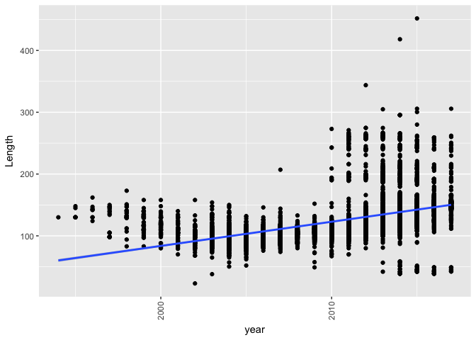

```r
md %>% filter(!is.na(year) & !is.na(dim_length) & !is.na(dim_breadth) & !is.na(dim_thickness)) -> yearedmd
ggplot(yearedmd, aes(y = dim_length, x = year)) + geom_point() + theme(axis.text.x=element_text(angle=90,hjust=1,vjust=0.5)) + labs(y = "Length") + geom_smooth(method='lm')
```

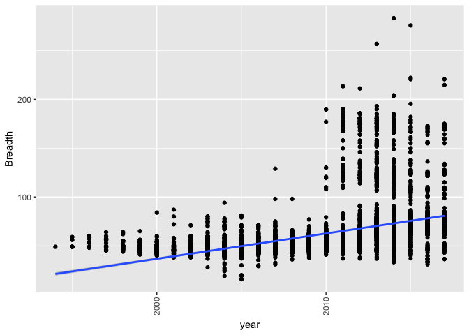

```r
ggplot(yearedmd, aes(y = dim_breadth, x = year)) + geom_point() + theme(axis.text.x=element_text(angle=90,hjust=1,vjust=0.5)) + geom_smooth(method='lm') + labs(y = "Breadth")
```

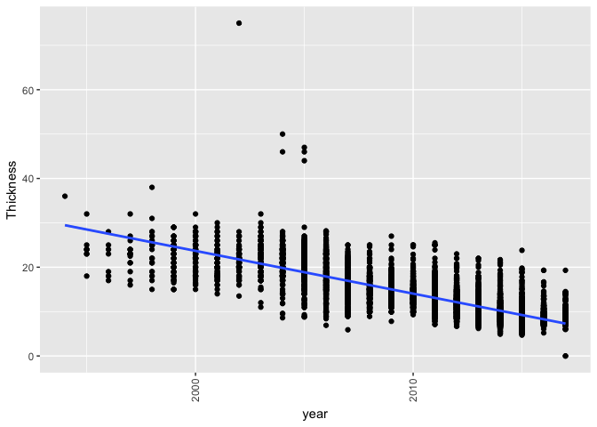

```r
ggplot(yearedmd, aes(y = dim_thickness, x = year)) + geom_point() + theme(axis.text.x=element_text(angle=90,hjust=1,vjust=0.5)) + geom_smooth(method='lm') + labs(y = "Thickness")
```

۳. نمودار ستونی متوسط قیمت گوشی بر حسب تعداد سیم کارت و دسترسی به LTE را رسم نمایید.

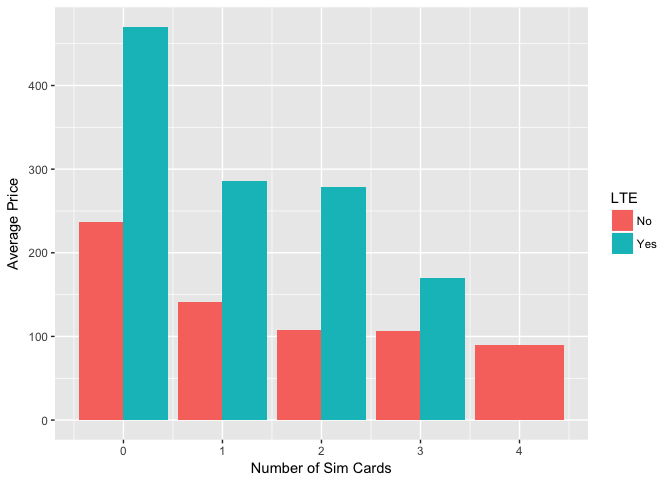

```r
md %>% filter(price < 5000 & price >0) %>% group_by(LTE, sim_no) %>% summarise(av = sum(price)/n()) %>% select(LTE, sim_no, av) -> sim_price
ggplot(sim_price, aes(x=sim_no, y=av, fill = LTE))  + geom_col(position = "dodge") + labs(x = "Number of Sim Cards") + labs(y="Average Price")
```

۴. نمودار جعبه ایی ضحامت گوشی هایی که در سال ۲۰۱۷ معرفی شده اند را برحسب اینکه کمیت جک هدفون رسم نمایید

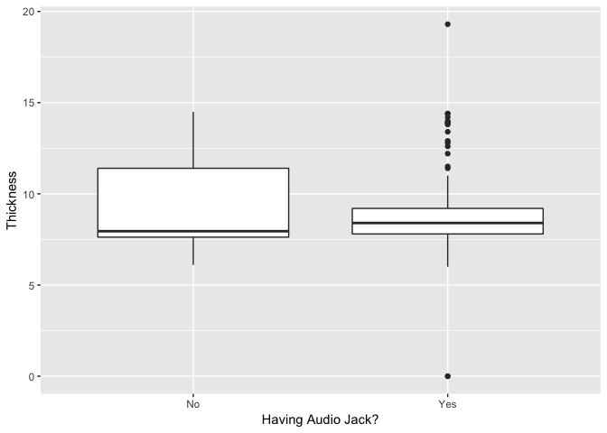

```r
md %>% filter(year == 2017 & !is.na(audio_jack) & !is.na(dim_thickness)) -> jack2017
ggplot(jack2017, aes(y=dim_thickness, x=audio_jack))  + geom_boxplot() + labs(y = "Thickness") + labs(x="Having Audio Jack?")
```

۵. مفهوم ppi را در گوشی های موبایل محاسبه و هیستوگرام آن را رسم نمایید. همچنین نمودار سالانه متوسط این کمیت را بکشید. کدام گوشی بیشترین ppi را دارد؟

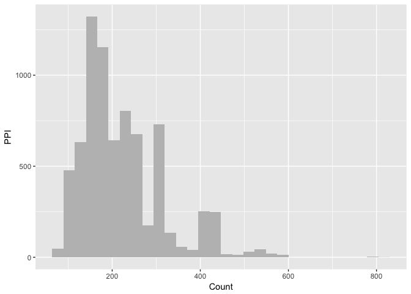

```r
md %>% mutate(ppi = sqrt(px_row**2 + px_col**2) / display_size) %>% filter(!is.na(ppi)) -> mppi
ggplot(mppi, aes(x=ppi))  + geom_histogram(fill = "gray") + labs(x = "Count") + labs(y="PPI")
```

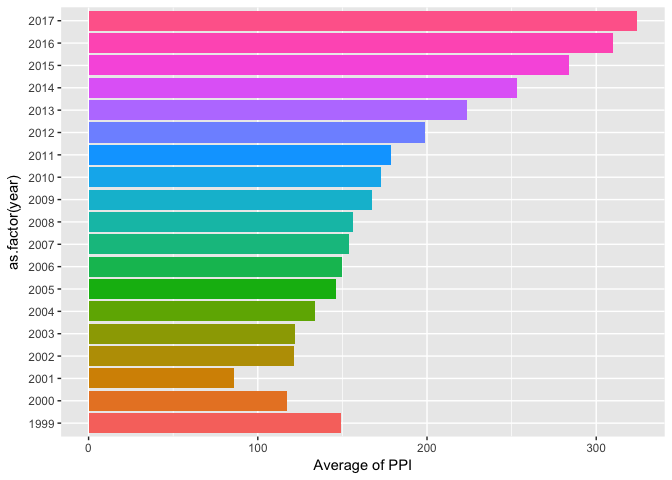

```r
mppi %>% filter(!is.na(year)) %>%  group_by(year) %>% summarise(avg = mean(ppi)) -> yearppi
ggplot(yearppi, aes(x=as.factor(year), y=avg, fill = as.factor(year))) + geom_col() + labs(y = "Average of PPI") + coord_flip() + guides(fill=FALSE)
```

و برای مشخص کردن گوشی دارای بالاترین ppi صفحه داریم:

```r
mppi %>% arrange(desc(ppi)) %>% head(1) %>% select(company, device, ppi)
```

```
## # A tibble: 1 x 3
##   company            device      ppi
##    <fctr>            <fctr>    <dbl>
## 1    Sony Xperia XZ Premium 806.9257
```

۶. در گذشته به بعضی از مدل های گوشی نوکیا **گوشکوب** گفته می شد. سعی کنید برای این مفهوم کمیتی مناسب تعریف کنید . ده گوشکوب برتر را پیدا کرده و نمودار گوشکوبیت آن را رسم نمایید.

من مفهوم گوشکوبیت را برار ضخامت تقسیم بر اندازه صفحه نمایش می دانم. زیرا طبق شهودم گوشی هایی که ضخامت زیادی دارند در مقابل صفحه نمایش کوچکشان احتمالا از مقاومت خوبی برخوردارند و گوشکوب خوبی هستند! پس از بررسی خروجی های به دست آمده از این تعریف به نظرم معیار خوبی برای گوشکوبیت بوده است.

```r
md %>% filter(!is.na(dim_thickness) & !is.na(display_size) & display_size > 1.5) %>% mutate(gushkubiat = dim_thickness/display_size) %>% arrange(desc(gushkubiat)) %>% select(company, device, gushkubiat) %>% head(10) -> top10gushkub
top10gushkub
```

```
## # A tibble: 10 x 3
##          company           device gushkubiat
##           <fctr>           <fctr>      <dbl>
##  1       Samsung             Z110   22.72727
##  2       Samsung             X810   15.00000
##  3 Sony Ericsson             W300   14.45783
##  4           NEC             N710   14.44444
##  5     VK Mobile           VK4100   14.38889
##  6         Nokia             6810   14.37500
##  7       Philips             S890   14.24419
##  8      Motorola             V980   14.21053
##  9      Motorola             V975   14.21053
## 10         Sonim XP3.20 Quest Pro   14.12429
```

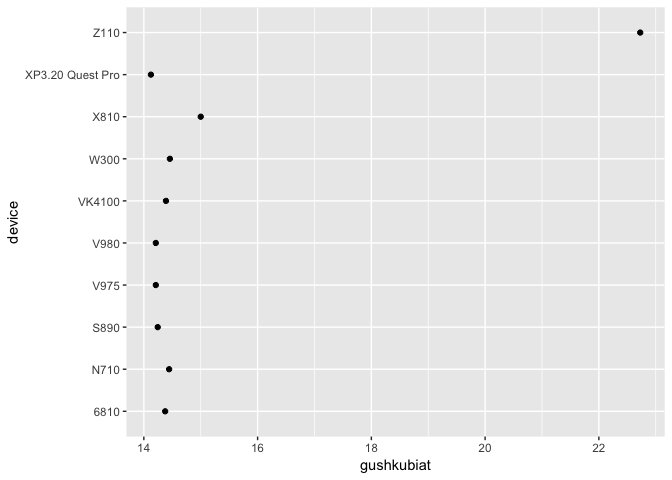

```r
ggplot(top10gushkub, aes(y = gushkubiat, x = device)) + geom_point() + coord_flip()
```

۷. آیا تلفن همراهی وجود دارد که در آب غرق نشود؟ اگر جواب بله هست تمام گوشی های که این خاصیت را دارند بیابید. با کشیدن یک نمودار به این سوال پاسخ دهید.

```r
md %>% mutate(density = 1000*weight/(dim_length*dim_breadth*dim_thickness)) %>% select(device, density) %>% filter(!is.na(density) & density<3) -> mdensity
mdensity %>% filter(density<1)
```

```
## # A tibble: 1,014 x 2
##    device   density
##    <fctr>     <dbl>
##  1   2040 0.9885380
##  2 OT-308 0.9829620
##  3 OT-292 0.8799580
##  4 OT-228 0.8972518
##  5 OT-665 0.9946470
##  6 OT-361 0.9356439
##  7 OT-223 0.9150865
##  8 OT-217 0.8830098
##  9 OT-213 0.8683022
## 10 OT-209 0.8946144
## # ... with 1,004 more rows
```

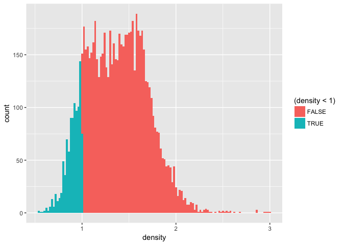

```r
ggplot(mdensity, aes(x=density, fill = (density<1))) + geom_histogram(binwidth = 0.02)
```

۸. نمودار پراکنش حجم ذخیره سازی باطری و وزن را رسم نمایید. میزان همبستگی بین این دو کمیت را محاسبه کنید.

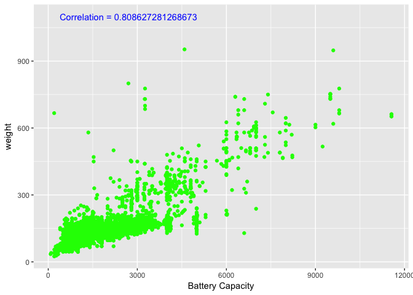

```r
md %>% filter(!is.na(battery_mah) & !is.na(weight)) -> bwd
ggplot(bwd) + geom_point(aes(x = battery_mah, y = weight), color = "green") + labs(x = "Battery Capacity") + annotate(geom="text", x=2700, y=1100, label=paste0("Correlation = ", cor(bwd$battery_mah, bwd$weight, method = "pearson")), color="blue")
```

۹. قیمت پرچمداران یک برند خاص مثلا سامسونگ را بیابید و نمودار قیمت زمان و نام مدل را رسم نمایید.

بهترین تعریفی که برای پرچمدار به ذهنم رسید، گرانترین موبایل تولید شده در هر سال توسط یک کمپانی بود که به دلیل بهترین خروجی در گوشی های تولید شده توسط اپل، این شرکت برای بررسی در نظر گرفته شد.

```r
md %>% filter(company == "Apple" & display_size >3 & display_size < 7 & !is.na(price)) %>% group_by(year) %>% summarise(price = max(price), model = device[which(price == max(price))]) -> bwd
bwd
```

```
## # A tibble: 11 x 3
##     year price          model
##    <int> <dbl>         <fctr>
##  1  2007   420         iPhone
##  2  2008    90      iPhone 3G
##  3  2009   110     iPhone 3GS
##  4  2010   200       iPhone 4
##  5  2011   190      iPhone 4s
##  6  2012   340       iPhone 5
##  7  2013   330      iPhone 5s
##  8  2014   520  iPhone 6 Plus
##  9  2015   630 iPhone 6s Plus
## 10  2016   830  iPhone 7 Plus
## 11  2017  1150       iPhone X
```

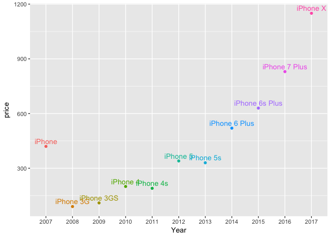

```r
ggplot(bwd, aes(x = as.factor(year), y = price, color = as.factor(year))) + geom_point() + geom_text(aes(label=model),hjust=.5, vjust=-0.5) + labs(x = "Year") + guides(color=FALSE)
```

۱۰. سه نمودار جالب رسم کنید و توضیح دهید چرا از نظر شما جالب است؟

بررسی روند افزایش تعداد معرفی گوشی ها طی زمان:  
نمودار به دست آمده نشان می دهد تا سال ۲۰۱۴ تقریبا تعداد معرفی ها هر ساله با افزایش مواجه بود، در حالی که از سال ۲۰۱۴ تا ۲۰۱۷ این تعداد با کاهش مواجه بوده است.

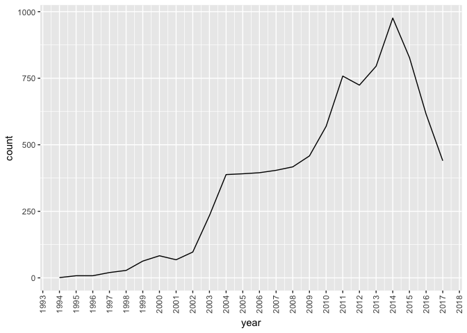

```r
md %>% filter(!is.na(year)) %>%  group_by(year) %>% summarise(count = n()) -> yrcountmd
ggplot(yrcountmd, aes(y = count, x = year)) + geom_freqpoly(stat = "identity", binwidth = 10) + scale_x_continuous(breaks = seq(1990, 2020, by = 1)) + theme(axis.text.x=element_text(angle=90,hjust=1,vjust=0.5))
```

بررسی درصد استفاده از سیستم عامل اندروید در دستگاه های مختلف بر حسب زمان:  
نمودار جالب به دست آمده نشان می دهد با توجه به اینکه تا سال ۲۰۰۸ درصد استفاده از سیستم عامل اندروید در دستگاه ها به ۰ میل می کرد، این عدد با افزایشی نمایی از سال۲۰۱۲ به ۱۰۰ درصد نزدیک می شود.

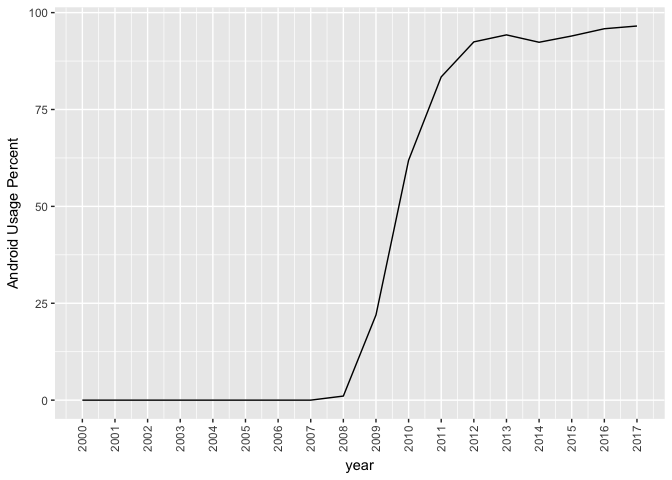

```r
md %>% filter(!is.na(year) & !is.na(os_type)) %>%  group_by(year) %>% summarise(androidusage = sum(os_type == "Android ") / n() * 100) -> androidmd
ggplot(androidmd, aes(y = androidusage, x = year)) + geom_freqpoly(stat = "identity", binwidth = 10) + scale_x_continuous(breaks = seq(1990, 2020, by = 1)) + theme(axis.text.x=element_text(angle=90,hjust=1,vjust=0.5)) + labs(y = "Android Usage Percent")
```

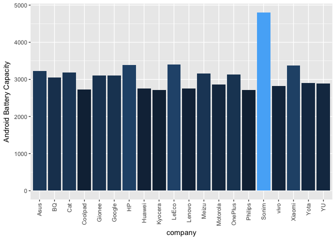

```r
md %>% filter(!is.na(company) & !is.na(battery_mah) & year > 2012 & display_size > 3 & display_size < 7) %>%  group_by(company) %>% summarise(av = mean(battery_mah)) %>% arrange(desc(av)) %>% head(20) -> batterycompany
ggplot(batterycompany, aes(x=company, y=av, fill = av)) + geom_col() + labs(y = "Android Battery Capacity") + guides(fill=FALSE) + theme(axis.text.x=element_text(angle=90,hjust=1,vjust=0.5))
```